# Superheroes

## Présentation du projet

La visualisation des données permet de voir l’histoire qui se cache derrière les chiffres. Il s’agit de ce fait d’un outil puissant pour partager et communiquer des informations.

Pour ce projet, nous allons visualiser les données du dataset **Superheroes** que nous avons crée lors du projet de data mining.

#### Petit rappel :

Le dataset **Superheroes** est composé de 283 observations décrites par 18 variables :

| Variable | Description | Exemple |
| --- | --- | --- |
| name | nom du superhéros | Spider-man |
| full.name | identité du superhéros | Peter Parker |
| class | indicateur général de combat | 10 |
| intelligence | statistique (0-100) | 95 |
| strength | statistique (0-100) | 55 |
| speed | statistique (0-100) | 65 |
| durability | statistique (0-100) | 75 |
| power | statistique (0-100) | 75 |
| combat | statistique (0-100) | 95 |
| publisher | éditeur | Marvel Comics |
| alignment | alignement | Good (gentil) |
| gender | genre | Male |
| race | race | Human (humain) |
| height.cm | taille en cm | 178 |
| weight.kg | poids en kg | 74 |
| eye.color | couleur des yeux | Hazel (noisette) |
| hair.color | couleur des cheveux | Brown (marron) |
| url | url de l’image du superhéro | https://www.superherodb.com/pictures2/portraits/10/100/133.jpg |

## Importation du fichier

Pour commencer, nous allons tout d’abord charger la librairie *ggplot2*, puis nous allons importer notre fichier pour créer le dataframe dans notre environement et commencer la visualisation.

```r
library(ggplot2)

# load Superheroes data for analysis
Superheroes <- read.csv("superheroes.csv")
```

## Visualisation des données quantitatives

### Corrélogramme

Pour commencer, mettons en évidence les corrélations entre les variables quantitatives avant de dresser les graphes grâce à un corrélogramme.

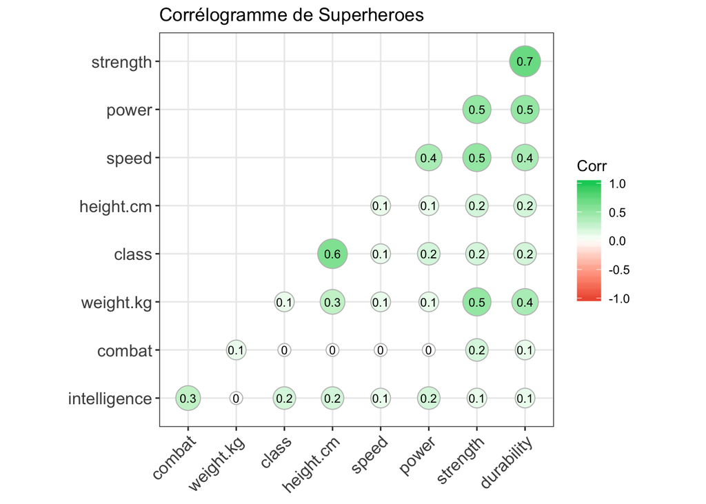

```r
library(dplyr)
library(ggcorrplot)
# Correlation matrix
corr <- round(cor(select(Superheroes, class, intelligence, strength, speed, durability, power, combat, height.cm, weight.kg)), 1)

# Correlogram of Superheroes
ggcorrplot(corr, hc.order = TRUE,
           type = "lower",
           lab = TRUE,
           lab_size = 3,
           method = "circle",
           colors = c("tomato2", "white", "springgreen3"),
           title = "Corrélogramme de Superheroes",
           ggtheme = theme_bw)
```

Nous remarquons que nous avons uniquement des corrélations positives avec *Streng/Durability* et *Class/Height* les deux corrélations les plus importantes. Elles restent cependant de qualité **moyenne**.

Ce qui est intéressant c’est la corrélation *Class/Height*. En effet, la ‘classe’ est un indicateur général de pouvoir, et parmis toutes les variables de statistique, celle qui est la plus corrélée positivement avec la classe c’est la taille.

Voyons cela de plus près :

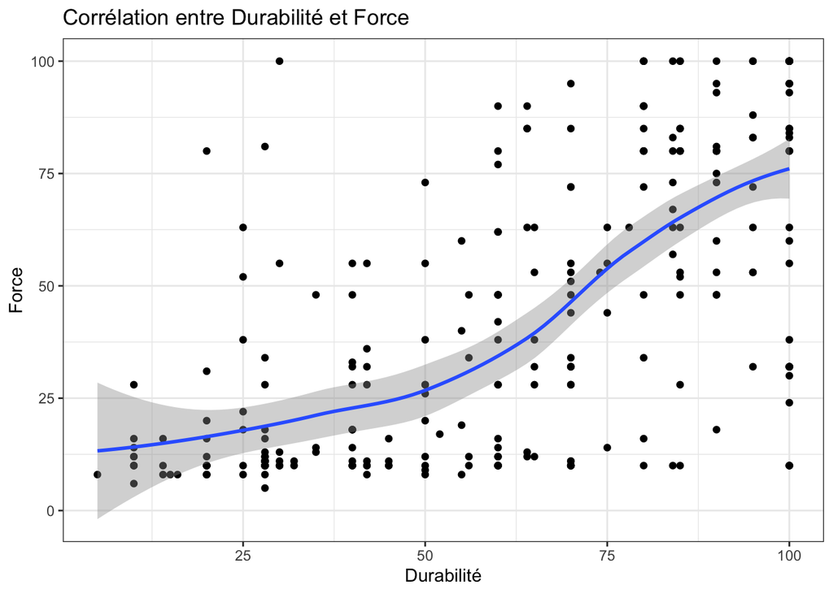

```r
#Corrélation entre Durabilité et Strength
ggplot(Superheroes, aes(x = durability, y = strength))+
  theme_bw() +
  geom_point() +
  geom_smooth() +
  labs(title = "Corrélation entre Durabilité et Force", x = "Durabilité", y = "Force")
```

Dans le graphe ci dessus, nous pouvons voir qu’il y a une corrélation de qualité moyenne entre la **Durabilité** et la **Force**.

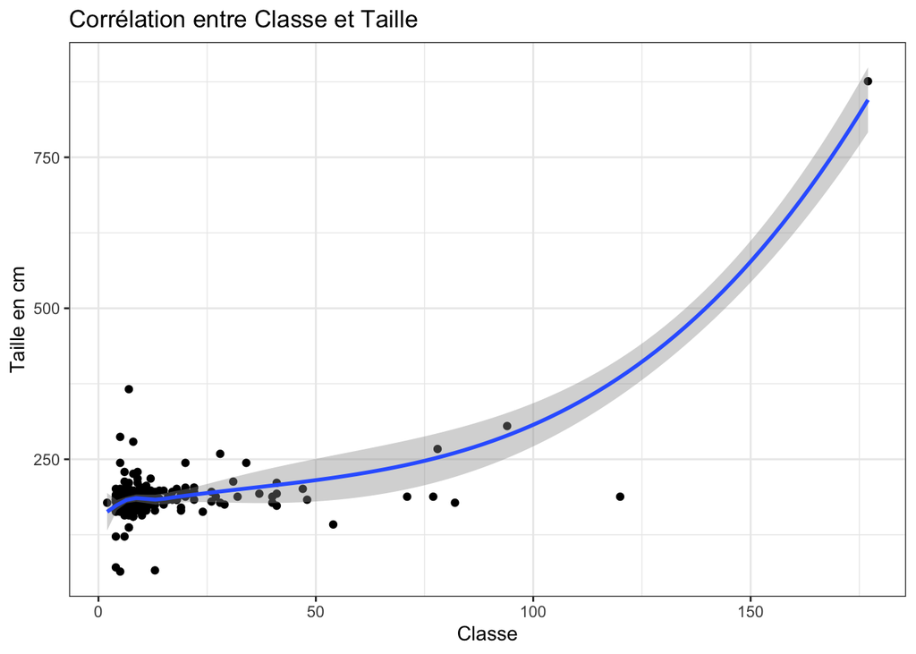

```r
#Corrélation entre Classe et Taille
ggplot(Superheroes, aes(x = class, y = height.cm)) +
  theme_bw() +
  geom_point() +
  geom_smooth() +
  labs(title = "Corrélation entre Classe et Taille", x = "Classe", y = "Taille en cm")
```

Ici, nous pouvons voir que la corrélation entre la classe et la taille est à nuancer. En effet, l’individu avec la plus grande taille est celui qui appartient à la classe la plus élévée. Cet individu est évidement un **outlier** qui influence fortement le coefficient de corrélation. Sans lui, il n’y aurai pas de corrélation.

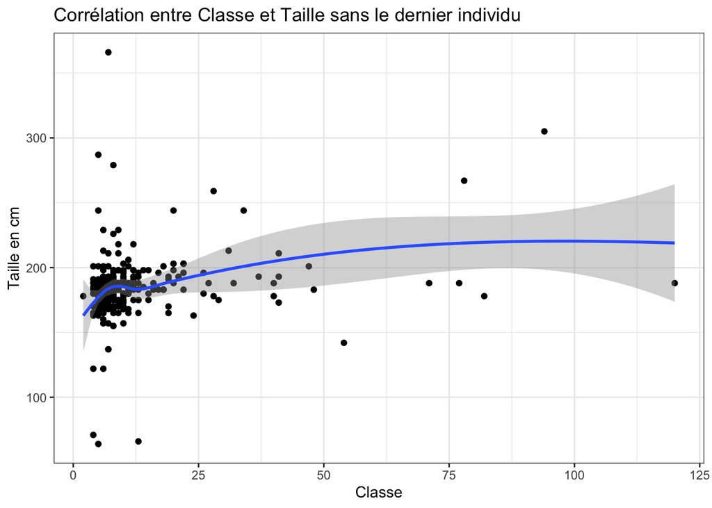

```r
#Corrélation entre Classe et Taille
ggplot(filter(Superheroes, height.cm < max(height.cm)), aes(x = class, y = height.cm)) +
  theme_bw() +
  geom_point() +
  geom_smooth() +
  labs(title = "Corrélation entre Classe et Taille sans le dernier individu", x = "Classe", y = "Taille en cm")
```

> Pour plus de visualisation des corrélations; notre application Shiny nous permet de voir la corrélation entre toutes les différentes variables quantitatives.

## Visualisation des données qualitatives

### Visualisation de l’alignement en fonction du genre

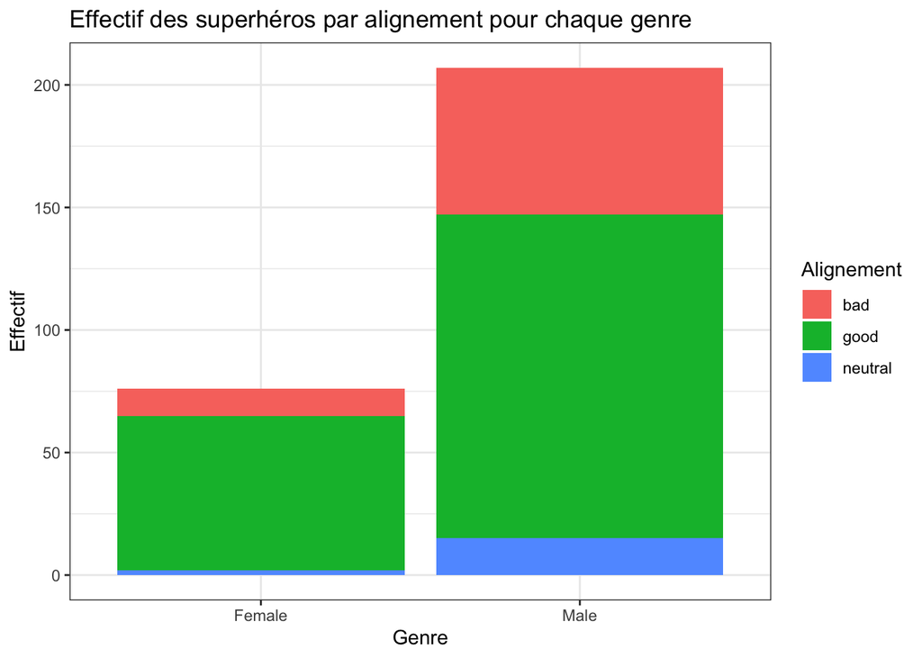

```r
ggplot(Superheroes, aes(x = gender, fill = alignment)) +
  theme_bw() +
  geom_bar() +
  labs(title = "Effectif des superhéros par alignement pour chaque genre", x = "Genre", y = "Effectif", fill = "Alignement")
```

On remarque que :

- Il y a plus de gentils que de méchants ou neutres
- Il y a plus de superhéros que de superhéroines
- La majorité des superhéroines sont gentilles
- Il y a plus de diversité de l’alignement chez les superhéros que les superhéroines
- Il y a très peu de neutres

### Visualisation de l’éditeur en fonction du genre

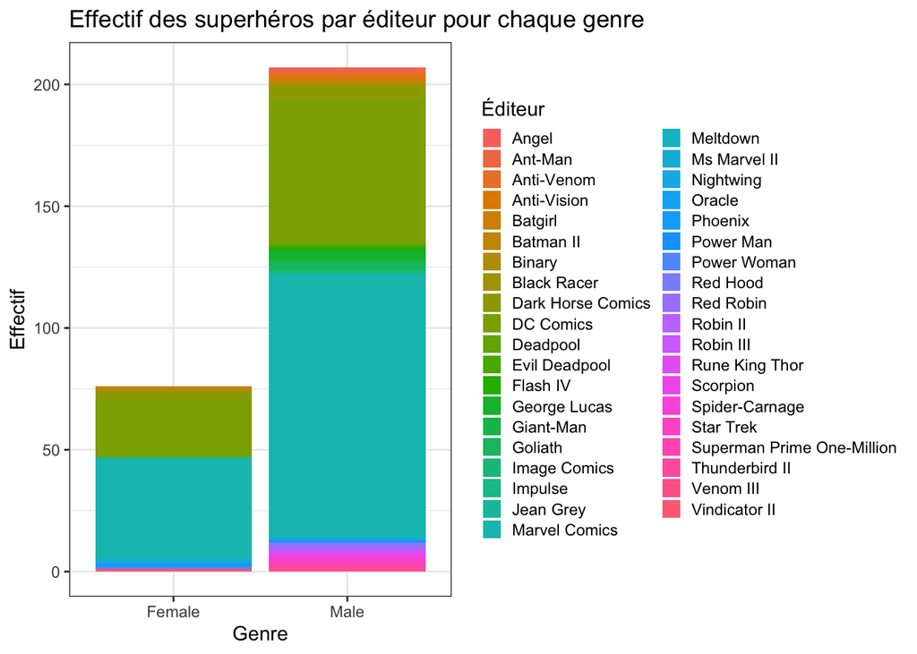

```r
ggplot(Superheroes, aes(x = gender, fill = publisher)) +
  theme_bw() +
  geom_bar() +
  labs(title = "Effectif des superhéros par éditeur pour chaque genre", x = "Genre", y = "Effectif", fill = "Éditeur") +
  theme(legend.position = "right", legend.key.size = unit(0.4, "cm"), legend.key.width = unit(0.4,"cm"))
```

On remarque que :

- Les superhéroines apparaissent plus chez éditeurs classique comme DC Comics et Marvel Comics
- Les superhéros males ont plus tendance à avoir un éditeur propre à leur personnage
- Plus de variété dans les éditeurs chez les superhéros que les superhéroines

### Visualisation de l’intelligence par alignement pour chaque genre

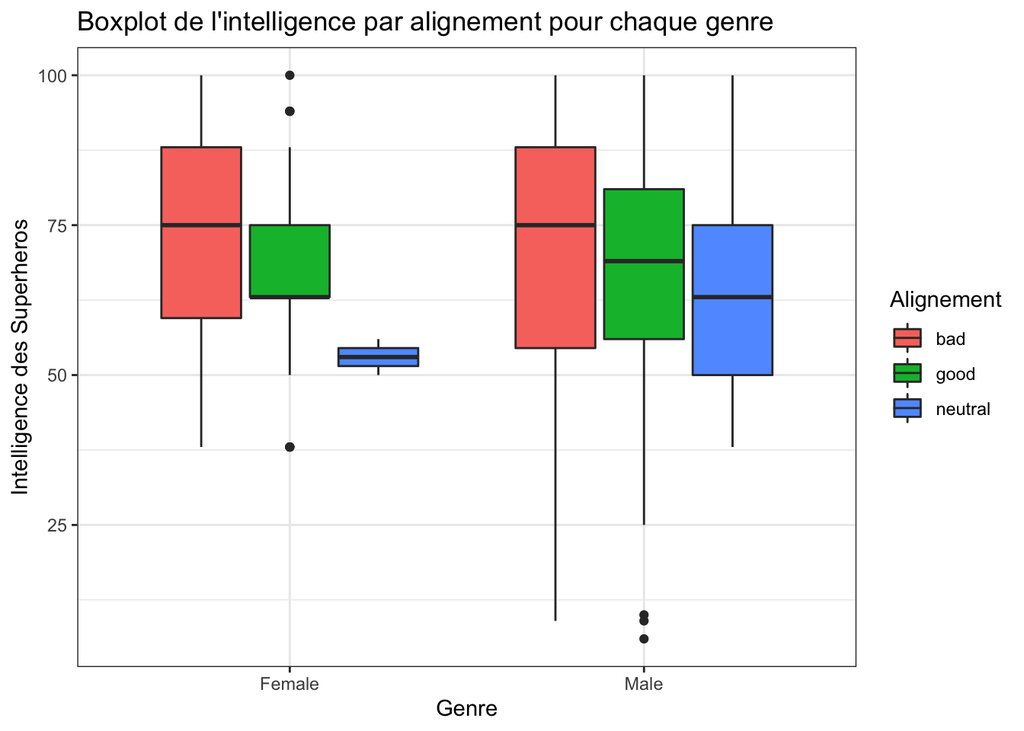

```r
ggplot(Superheroes, aes(x = gender, y = intelligence, fill = alignment)) +
  theme_bw() +
  geom_boxplot() +
  labs(title = "Boxplot de l'intelligence par alignement pour chaque genre", x = "Genre", y = "Intelligence des Superheros", fill = "Alignement")
```

On remarque que :

- Les vilains ont des valeurs plus importantes que les autres
- L’intelligence est mieux dispersée chez les superhéros que les superhéroines
- Le boxplot des superhéroines gentilles et neutres est plus petit que les autre, les valeurs sont donc plus proches

### Visualisation de la race en fonction de l’alignement

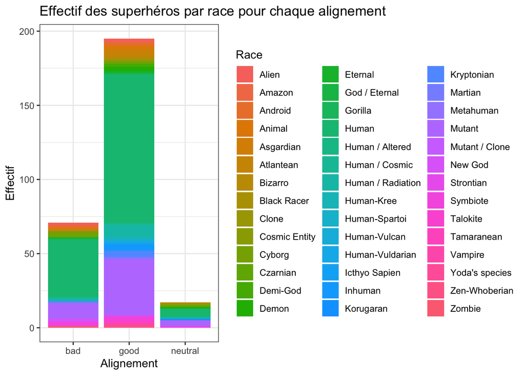

```r
ggplot(Superheroes, aes(x = alignment, fill = race)) +
  theme_bw() +
  geom_bar() +
  labs(title = "Effectif des superhéros par race pour chaque alignement", x = "Alignement", y = "Effectif", fill = "Race")
```

On remarque que :

- Il y a plus de gentils que de méchants
- Il y a une répartition similaire des races pour chqaue alignement
- Contrainement à ce qu’on pense, les humains ne sont pas tous gentils et les vilains ne sont pas tous non humains

### Visualisation de la couleur des yeux en fonction de l’alignement

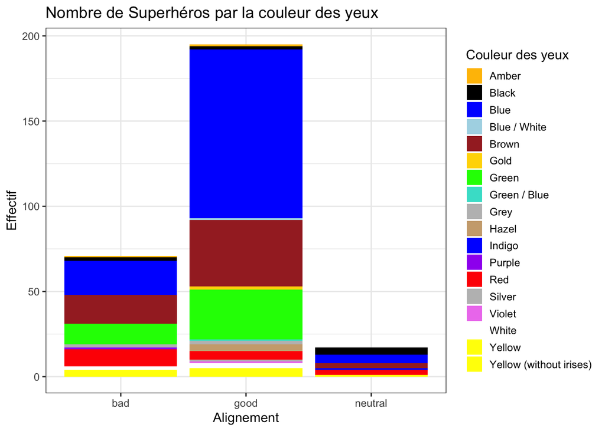

```r
ggplot(Superheroes,aes(x = alignment, fill = eye.color))+
  theme_bw() +
  geom_bar() +
  scale_fill_manual("Couleur des yeux", values = c("#FFBF00","Black","Blue","lightblue","Brown","Gold",
                                                   "Green","Turquoise","Grey","burlywood3","blue","Purple",
                                                   "Red","gray","Violet","White","Yellow", "Yellow")) +
  theme(legend.position = "right", legend.key.size = unit(0.5, "cm"), legend.key.width = unit(0.5,"cm"))  +
  labs(title="Nombre de Superhéros par la couleur des yeux", x = "Alignement", y= "Effectif")
```

### Visualisation de la couleur des cheveux en fonction de l’alignement

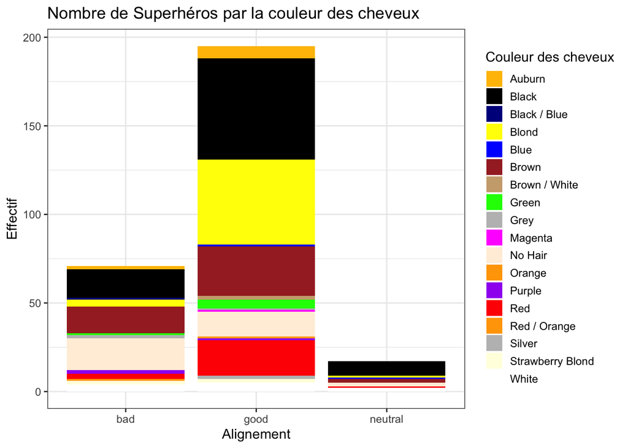

```r
ggplot(Superheroes,aes(x = alignment, fill = hair.color))+
  theme_bw() +
  geom_bar() +
  scale_fill_manual("Couleur des cheveux", values = c("#FFBF00","Black","darkblue","Yellow","Blue",
                                                      "Brown","burlywood3","Green","Grey","Magenta",
                                                      "antiquewhite1","Orange","Purple","Red",
                                                      "Orange","Grey","lightyellow","white")) +
  theme(legend.position = "right", legend.key.size = unit(0.5, "cm"), legend.key.width = unit(0.5,"cm"))  +
  labs(title="Nombre de Superhéros par la couleur des cheveux", x = "Alignement", y = "Effectif", fill = "Couleur des cheveux")
```

En ce qui concerne l’apparence des superhéros, on peut en déduire un stéréotype. En effet, on peut voir que les gentils ont majoriterement les yeux bleus et qu’il y a plus de blonds chez les gentils que les vilains.

On peut donc dire que les superhéros **blonds** aux yeux **bleus** sont plus probablements gentils. C’est l’image stéréotype qu’on a tous du superhéros.